# IODS course project

Rekar Abdulhamed

## Introduction to Open Data Science - Course Project

# About the project

This is my RMD-output site for course exercises in Open Data Science MOOC-course. My repository for this course can be found [here](https://github.com/Rad-ish/IODS-project)

I’m new to version control in github, so let’s see if this becomes a habit. :)

Done: * Registered to github, installed it and pushed my first files * Committed and pushed updated files to git

# Exercise 2

#### Read the wrangled data

This data consist of seven variables and 166 observations. The data was collected in 2014 (Vehkalahti, 2014) from students attending to a statistics in social sciences course. The survey assessed attitudes towards statistics, individual learning styles and points achieved in the course by the individual. In the data used here, items have been aggregated (Attitude, deep, strat, surf), and divided by the N of items. Further, rows where Points = 0 were removed from the dataset (N = 183, after removing zeros, N = 166). **Find my R-file for data wrangling [here](https://github.com/Rad-ish/IODS-project/blob/master/data/create_learning2014.R).**

More information of the dataset at hand can be found [here](https://www.mv.helsinki.fi/home/kvehkala/JYTmooc/JYTOPKYS3-meta.txt)

*Kimmo Vehkalahti: ASSIST 2014 - Phase 3 (end of Part 2), N=183 Course: Johdatus yhteiskuntatilastotieteeseen, syksy 2014 (Introduction to Social Statistics, fall 2014 - in Finnish), international survey of Approaches to Learning, made possible by Teachers’ Academy funding for KV in 2013-2015.*

```r
setwd("C:/Users/rekar/Documents/Road to PhD/Kurssit/Open data science/IODS-project/data")
lrn <- read.csv("lrn.csv")



library(tidyverse)
library(viridis)

#Rename gender variable for plotting purposes
lrn <-
  lrn %>%
  mutate(gender=recode(gender, "M"="Male", "F"="Female"))




head(lrn)
```

```
##   gender Age Attitude     deep  stra     surf Points
## 1 Female  53      3.7 3.583333 3.375 2.583333     25
## 2   Male  55      3.1 2.916667 2.750 3.166667     12
## 3 Female  49      2.5 3.500000 3.625 2.250000     24
## 4   Male  53      3.5 3.500000 3.125 2.250000     10
## 5   Male  49      3.7 3.666667 3.625 2.833333     22
## 6 Female  38      3.8 4.750000 3.625 2.416667     21
```

## Summarising and visualising data

Below you can find a summary of the data produced by describe from the psych-library. After this I examined the data visually using ggpairs. After this I ran two plots to show the distributions more clearly and further run a few geom_smooths for fun. I tried to add the viridis colouring to the ggpairs, but it didn’t get applicated to all of the plots. If you, dear student-peer-reviewer, have a solution to this, please comment your solution in the peer-review.

First we take a look at the distribution of age and gender, and we see that the males attending to this course were older than the females. Second we look at the distribution in attitudes towards statistics, where we find the mean (marked as an asterix) and median being higher among males. Third, I was interested if age had any association to the points acquired, for which a a loess smooth was calculated to overfit the data.

After this I plotted a few scatter plots with geom_smooths (OLS regressions) to assess relationships among variables. We find a clear relation between attitude and points earned in the course. After this relation of attitude was examined to learning styles. Visually this relationship seems to be only among males.

```r
#Using the psych library for extensive summary
library(psych)
library(GGally)
describe(lrn)
```

```
##          vars   n  mean   sd median trimmed  mad   min   max range  skew
## gender*     1 166  1.34 0.47   1.00    1.30 0.00  1.00  2.00  1.00  0.68
## Age         2 166 25.51 7.77  22.00   23.99 2.97 17.00 55.00 38.00  1.89
## Attitude    3 166  3.14 0.73   3.20    3.15 0.74  1.40  5.00  3.60 -0.08
## deep        4 166  3.68 0.55   3.67    3.70 0.62  1.58  4.92  3.33 -0.50
## stra        5 166  3.12 0.77   3.19    3.14 0.83  1.25  5.00  3.75 -0.11
## surf        6 166  2.79 0.53   2.83    2.78 0.62  1.58  4.33  2.75  0.14
## Points      7 166 22.72 5.89  23.00   23.08 5.93  7.00 33.00 26.00 -0.40
##          kurtosis   se
## gender*     -1.54 0.04
## Age          3.24 0.60
## Attitude    -0.48 0.06
## deep         0.66 0.04
## stra        -0.45 0.06
## surf        -0.27 0.04
## Points      -0.26 0.46
```

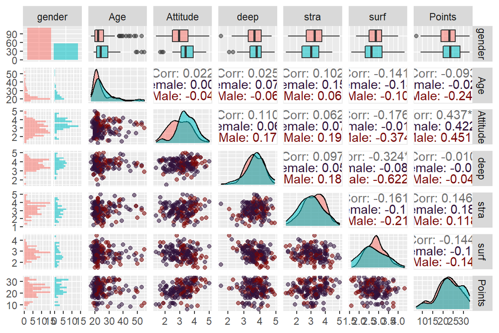

```r
ggpairs(lrn, mapping = aes(col=gender, alpha=0.2), lower=list(combo = wrap("facethist", bins =20))) + scale_colour_viridis_d(option = "H")
```

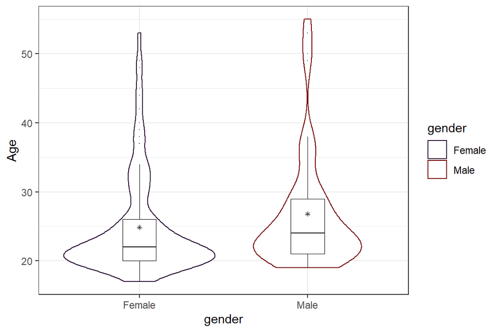

```r
#Age * sex
lrn %>%
  ggplot(aes(gender, Age, colour=gender)) +
  geom_violin() +
  scale_colour_viridis_d(option="H") +
    geom_boxplot(width=0.2, size=0.2, color="black", alpha=0.4, outlier.size = 0) +
    stat_summary(fun=mean, geom="point", size=1, color="black", shape=8) +
  theme_bw()
```

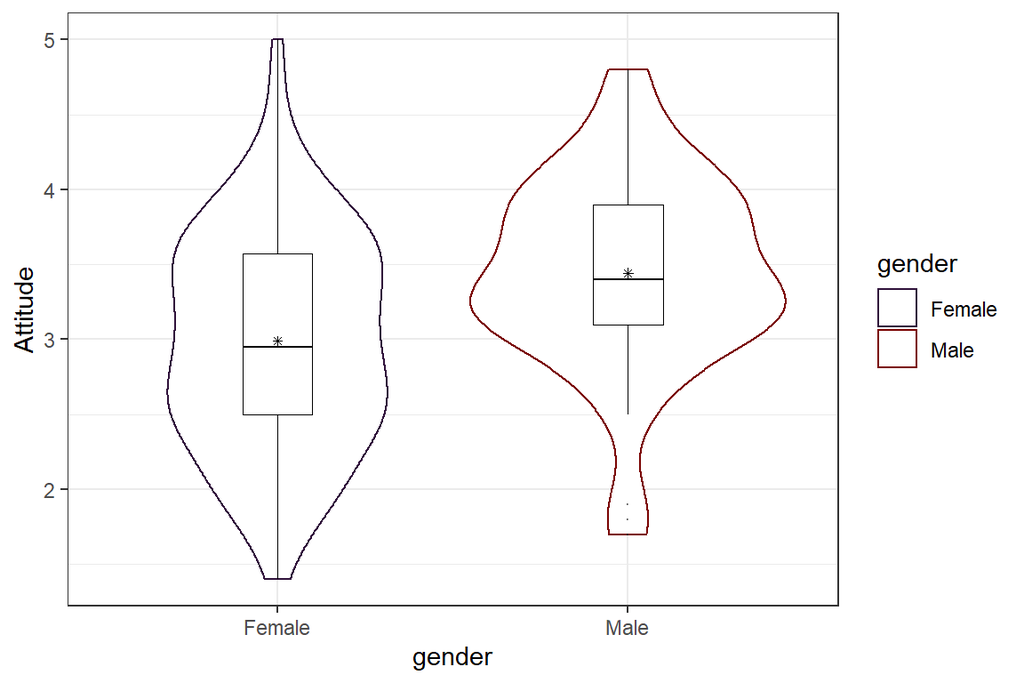

```r
#Attitud * Sex
lrn %>%
  ggplot(aes(gender, Attitude, color=gender)) +
  geom_violin() +
  scale_colour_viridis_d(option="H") +
    geom_boxplot(width=0.2, size=0.2, color="black", alpha=0.4, outlier.size = 0) +
    stat_summary(fun=mean, geom="point", size=1, color="black", shape=8) +
  theme_bw()
```

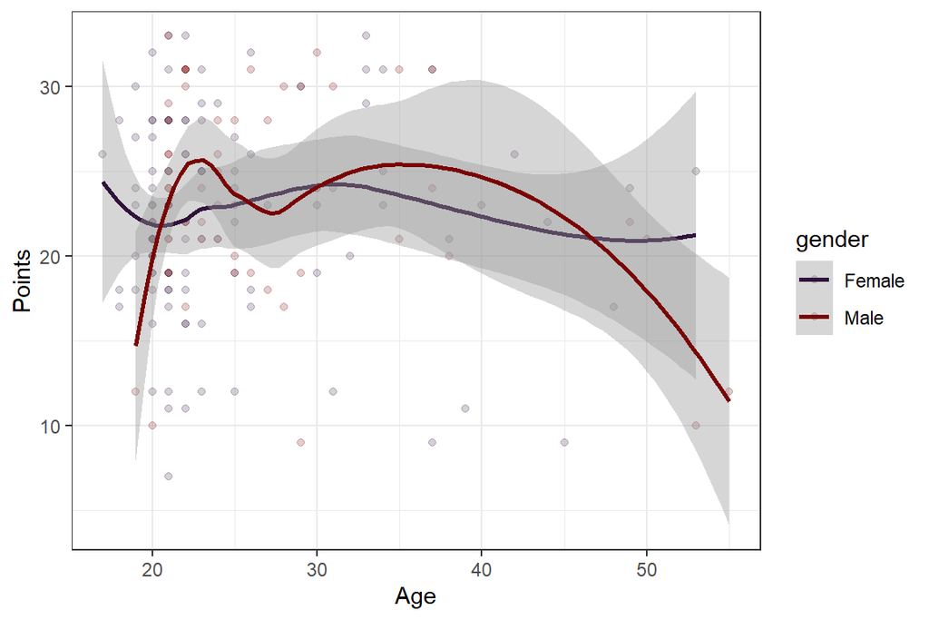

```r
#Age's relation to points
lrn %>%
  ggplot(aes(Age, Points, color=gender)) +
  geom_point(alpha=0.2) +
  geom_smooth(method=loess) +
  scale_colour_viridis_d(option="H") +
  theme_bw()
```

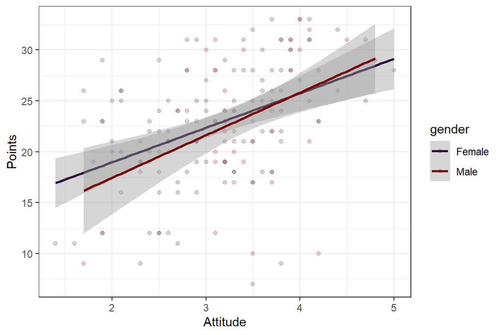

```r
#Attitude * points
lrn %>%
  ggplot(aes(Attitude, Points, color=gender)) +
  geom_point(alpha=0.2) +
  geom_smooth(method=lm) +
  scale_colour_viridis_d(option="H") +
  theme_bw()
```

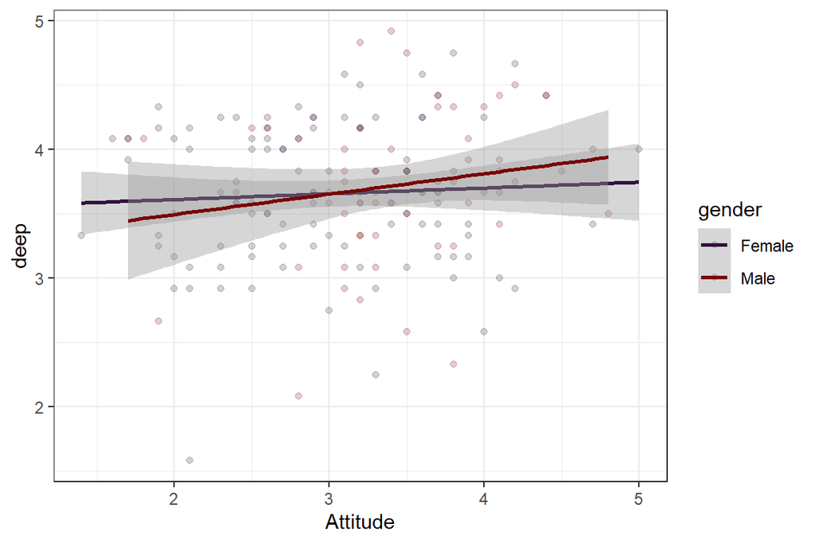

```r
#Attitude * learning style deep
lrn %>%
  ggplot(aes(Attitude, deep, color=gender)) +
  geom_point(alpha=0.2) +
  geom_smooth(method=lm) +
  scale_colour_viridis_d(option="H") +
  theme_bw()
```

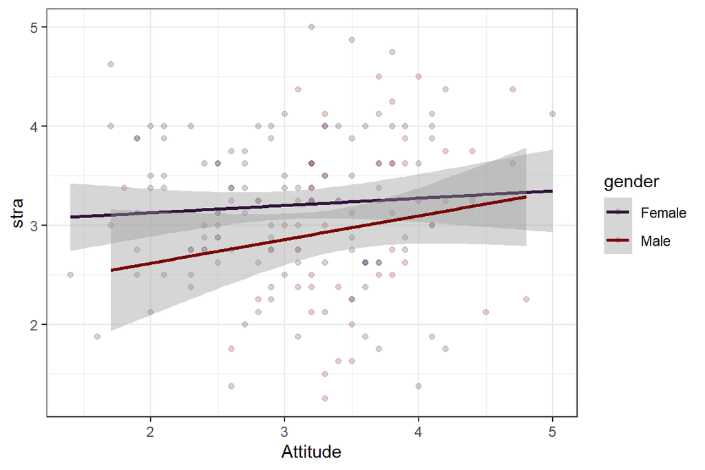

```r
#Attitude * learning strategy
lrn %>%
  ggplot(aes(Attitude, stra, color=gender)) +
  geom_point(alpha=0.2) +
  geom_smooth(method=lm) +
  scale_colour_viridis_d(option="H") +
  theme_bw()
```

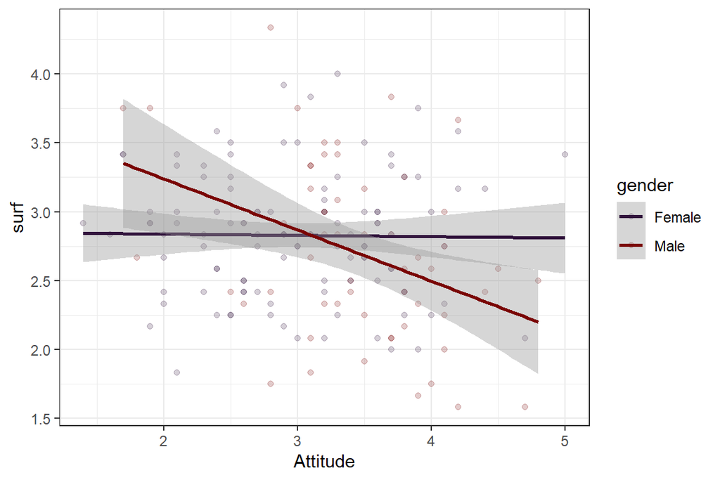

```r
#attitude + surface learning style
lrn %>%
  ggplot(aes(Attitude, surf, color=gender)) +
  geom_point(alpha=0.2) +
  geom_smooth(method=lm) +
  scale_colour_viridis_d(option="H") +
  theme_bw()
```

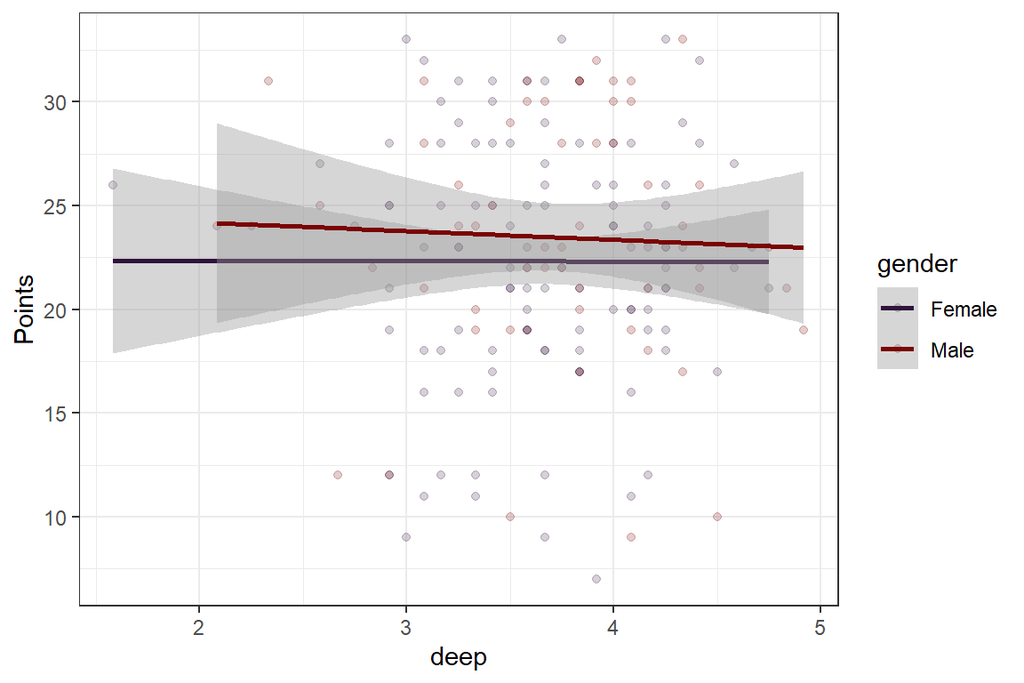

```r
#Learning style deep * points

lrn %>%
  ggplot(aes(deep, Points, color=gender)) +
  geom_point(alpha=0.2) +
  geom_smooth(method=lm) +
  scale_colour_viridis_d(option="H") +
  theme_bw()
```

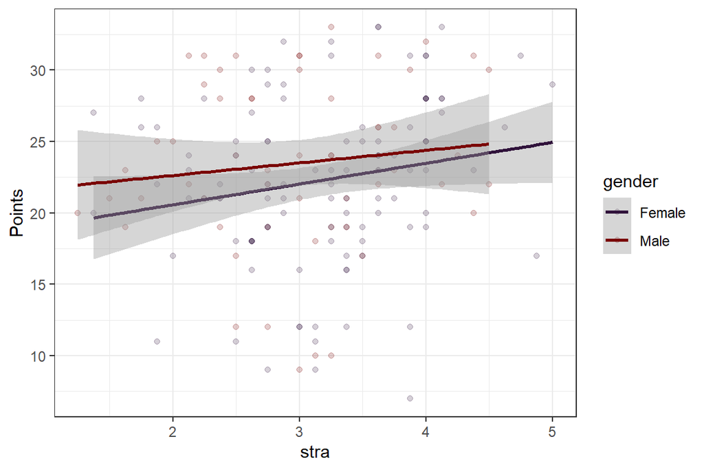

```r
lrn %>%
  ggplot(aes(stra, Points, color=gender)) +
  geom_point(alpha=0.2) +
  geom_smooth(method=lm) +
  scale_colour_viridis_d(option="H") +
  theme_bw()
```

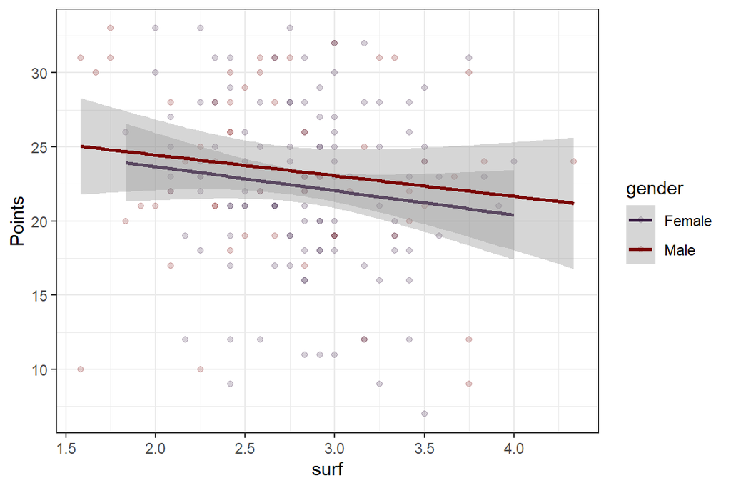

```r
lrn %>%
  ggplot(aes(surf, Points, color=gender)) +
  geom_point(alpha=0.2) +
  geom_smooth(method=lm) +
  scale_colour_viridis_d(option="H") +
  theme_bw()
```